# Business Statistics End of Term Assessment IB94X0 2024-2025 #1

### Modelling by delivery time with SES category interaction

To evaluate the effect of SES category to the impact of delivery time upon customer satisfaction, modelling with interaction is performed.

```r
p.deliv <- ggplot(data = cust, aes(x=delivery.time, y = customer.satisfaction))+
  geom_point(color = "grey")+
  geom_smooth(color = "black")+
  labs(
    title = "Customer Satisfaction vs delivery time",
    x = "delivery time",
    y = "customer satisfaction",
    caption = "Figure 2.3.a Customer satisfaction vs delivery time"
  )+
  theme(
    plot.title = element_text(size = 10),
    axis.title = element_text(size = 8),
    axis.text = element_text(size = 7),
    plot.caption = element_text(size = 6)
  )
  ylim(2,10)
```

```
## <ScaleContinuousPosition>
##  Range:
##  Limits:    2 --   10
```

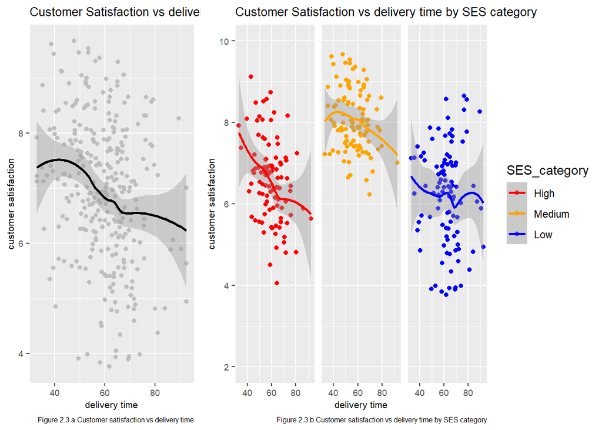

```r
p.deliv.ses<- ggplot(data = cust, aes(x=delivery.time, y = customer.satisfaction, color = SES_category))+
  geom_point()+
  geom_smooth()+
  labs(
    title = "Customer Satisfaction vs delivery time by SES category",
    x = "delivery time",
    y = "customer satisfaction",
    caption = "Figure 2.3.b Customer satisfaction vs delivery time by SES category"
  )+
  scale_color_manual(values = c("High" = "red", "Medium" = "orange", "Low" = "blue"))+
  facet_grid(. ~ SES_category, scales = "free", switch = "both") +
  theme(
    strip.text = element_blank(),
    plot.title = element_text(size = 10),
    axis.title = element_text(size = 8),
    axis.text = element_text(size = 7),
    plot.caption = element_text(size = 6)
        )+
  ylim(2,10)

grid.arrange(p.deliv, p.deliv.ses, ncol=2, widths=c(1,2))
```

Figure 2.3 shows the effect of delivery time towards customer satisfaction. Figure 2.3.a shows the impact of delivery time without considering the SES category, while Figure 2.3.b shows the impact of delivery time for each SES category. From the figure, it seems that for every SES category, delivery time has a negative impact on customer satisfaction. However, how each SES category will impact of delivery time upon customer satisfaction will be discussed in further analysis.

```r
m.custsat.by.delivtime.SES <- lm (customer.satisfaction~delivery.time*SES_category, data = cust)
summary (m.custsat.by.delivtime.SES)
```

```
##
## Call:
## lm(formula = customer.satisfaction ~ delivery.time * SES_category,
##     data = cust)
##
## Residuals:
##      Min       1Q   Median       3Q      Max
## -2.43290 -0.63000  0.00057  0.72673  2.52903
##
## Coefficients:
##                                  Estimate Std. Error t value Pr(>|t|)
## (Intercept)                       8.62092    0.57199  15.072  < 2e-16 ***
## delivery.time                    -0.03471    0.00946  -3.669 0.000289 ***
## SES_categoryMedium                0.29635    0.76383   0.388 0.698310
## SES_categoryLow                  -2.12232    0.77457  -2.740 0.006519 **
## delivery.time:SES_categoryMedium  0.01937    0.01287   1.505 0.133336
## delivery.time:SES_categoryLow     0.02976    0.01253   2.374 0.018221 *
## ---
## Signif. codes:  0 '***' 0.001 '**' 0.01 '*' 0.05 '.' 0.1 ' ' 1
##
## Residual standard error: 0.9916 on 294 degrees of freedom
## Multiple R-squared:  0.4205, Adjusted R-squared:  0.4107
## F-statistic: 42.67 on 5 and 294 DF,  p-value: < 2.2e-16
```

Interpretation of the coefficients:

1.delivery.time: For each one unit of increase in delivery time, the customer satisfaction rate decreases by 0.034 points, which is significantly different from zero (t(294) = -3.669, p < 0.05).

2.SES category Medium: For the change of SES category from High to Medium, the customer satisfaction increases by 0.296. However, this change is not significantly different from zero (t(294) = 0.388, p = 0.698).

3.SES category Low: For the change of SES category from High to low, the customer satisfaction decreases by 2.122, which is significantly different from zero (t(294) = -2.740, p < 0.05).

4.delivery.time*SES category Medium: The change of SES category from High to Medium and for every increase of delivery time, the change in customer satisfaction becomes more positive by 0.019. However, this change is not significantly different from zero (t(294) = 1.505, p = 0.133)

5.delivery.time*SES category Low: The change of SES category from High to Low and for every increase of delivery time, the change in customer satisfaction becomes more positive by 0.030. This change is significantly different from zero (t(294) = 2.374, p < 0.05)

To compare between the model that predicts the customer satisfaction just with the delivery time and the model that predicts with the interaction of delivery time and SES category, ANOVA analysis is performed.

```r
anova(m.custsat.by.delivtime, m.custsat.by.delivtime.SES)
```

```
## Analysis of Variance Table
##
## Model 1: customer.satisfaction ~ delivery.time
## Model 2: customer.satisfaction ~ delivery.time * SES_category
##   Res.Df    RSS Df Sum of Sq     F    Pr(>F)
## 1    298 465.41
## 2    294 289.06  4    176.35 44.84 < 2.2e-16 ***
## ---
## Signif. codes:  0 '***' 0.001 '**' 0.01 '*' 0.05 '.' 0.1 ' ' 1
```

A graph is created based on the model’s predictions to illustrate how each SES category affects the impact of delivery time on customer satisfaction.

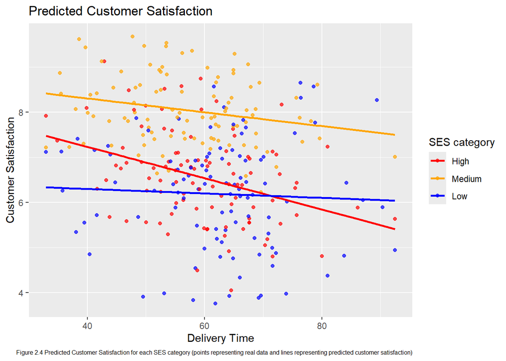

```r
custsatpred <- na.omit(cust) #removing na from cust dataset to prepare it for prediction

custsatpred$custsathat <- predict(m.custsat.by.delivtime.SES, custsatpred)

ggplot(custsatpred, aes(x = delivery.time, color = SES_category)) +
  geom_point(aes(y = customer.satisfaction), alpha = 0.7) +
  geom_line(aes(y = custsathat), size = 1) +
  scale_color_manual(values = c("High" = "red", "Medium" = "orange", "Low" = "blue"))+
  labs(
    title = "Predicted Customer Satisfaction",
    x = "Delivery Time",
    y = "Customer Satisfaction",
    color = "SES category",
    caption = "Figure 2.4 Predicted Customer Satisfaction for each SES category (points representing real data and lines representing predicted customer satisfaction)"
  )+
  theme (plot.caption = element_text(size = 6))
```

Figure 2.4 shows that the impact of delivery time on customer satisfaction is negative across all SES categories, with the High and Medium SES categories experiencing a relatively stronger negative effect, while the Low SES category shows a comparatively smaller negative effect on customer satisfaction.